# Qualitative Activity Recognition in Weight Lifting

Sever Fundatureanu

June 25, 2017

## Overview

This report shows how machine learning is used to predict the quality of a human activity such as weight lifting. We are using Human Activity Recognition data available [here](http://groupware.les.inf.puc-rio.br/har) with 5 classes (sitting-down, standing-up, standing, walking, and sitting) collected on 8 hours of activities of 4 healthy subjects. We achieve an estimated 99.4% accuracy with a random-forest model trained with 5-fold cross-validation.

## Exploratory Data Analysis

We dowload the datasets and load into dataframes:

```r
download.file("https://d396qusza40orc.cloudfront.net/predmachlearn/pml-training.csv", "training.csv")
training <- read.csv("training.csv")
download.file("https://d396qusza40orc.cloudfront.net/predmachlearn/pml-testing.csv", "testing.csv")
testing <- read.csv("training.csv")

dim(training)
```

```
## [1] 19622   160
```

We have 160 columns in total, so we need to check if all of them should be used as predictors. We check for columns with too many NA values:

```r
colNAs <- colSums(is.na(training))
nrows <- nrow(training)
# remove columns with more than 95% NAs
naCols <- names(colNAs[colNAs/nrows > 0.95])
validFeatures <- training[,-(which(names(training) %in% naCols))]
```

Next, we check for columns with low variance, since those will not contribute to our model fit. We use the function *nearZeroVar* from the *caret* package.

```r
require(caret, quietly = TRUE)
nearZeroVariance <- nearZeroVar(validFeatures, saveMetrics = TRUE)
nzVarianceColumns <- rownames(nearZeroVariance[nearZeroVariance$nzv==TRUE,])
```

We look at the remaining columns and notice a set of columns like user_name and timestamp, which are simply metadata for the experiment. These should not be used as predictors since they will be widely different if someone will try to reproduce the experiment. We also see that column X is dependant on the row index, so it’s just a row identifier in the dataset, thus irrelevant for our purposes.

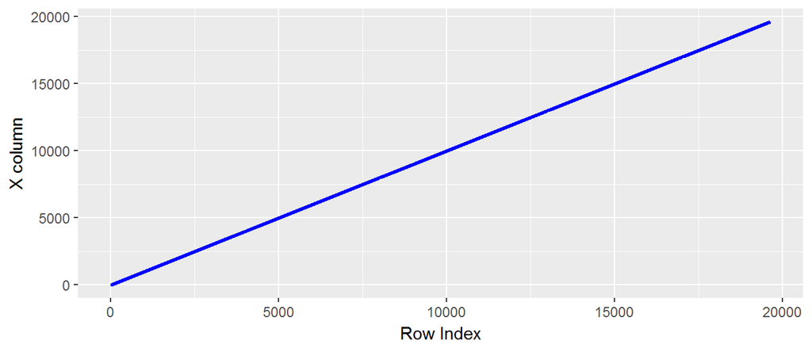

We union the NA columns with zero variance columns with the metadata columns and filter them out. We are left with a subset of 53 columns for downstream processing.

```r
metadataCols <- c("X", "user_name", "num_window", "raw_timestamp_part_1",
              "raw_timestamp_part_2", "cvtd_timestamp")
filterOutCols <- union(nzVarianceColumns, union(naCols, metadataCols))
newTrain <- training[,-(which(names(training) %in% filterOutCols))]
dim(newTrain)
```

```
## [1] 19622    53
```

## Choosing a Prediction Algorithm

We are trying to solve a classification problem, so we first try a boosting algorithm with 5-fold cross validation, since it has a good reputation. We use *caret*’s built-in cross-validation via the *trainControl* object.

```r
set.seed(1230)
tControl <- trainControl(method="cv", number=5)
gbmModel <- train(classe ~ ., data=newTrain, method="gbm", trControl=tControl, verbose<-FALSE)
accuracyIndex <- as.integer(rownames(gbmModel$bestTune))
gbmModel$results$Accuracy[accuracyIndex]
```

[output not shown]

We get an accuracy of 96.26% for the best tune from the results. Although this is quite good, the probability of predicting all 20 test results correctly will be $0.9626^{20}=0.4669$. 46.7% is not enough, we need to do better.

We next try a random forest algorithm, again with 5-fold cross validation to avoid overfitting the model. We parallelize the algorithm to improve performance.

```r
require(parallel, quietly = TRUE)
require(doParallel, quietly = TRUE)
cluster <- makeCluster(detectCores() - 1)
registerDoParallel(cluster)
tControl <- trainControl(method="cv", number=5)
rfModel <- train(classe ~ ., data=newTrain, method="rf",
                 trControl=tControl, allowParallel=TRUE)
```

```r
rfModel$results[rfModel$results$mtry==rfModel$bestTune$mtry,]
```

```
##   mtry Accuracy     Kappa AccuracySD     KappaSD
## 2   27 0.994649 0.9932312  0.0010342 0.001308157
```

```r
rfModel$finalModel
```

```
##
## Call:
##  randomForest(x = x, y = y, mtry = param$mtry, allowParallel = TRUE)
##                Type of random forest: classification
##                      Number of trees: 500
## No. of variables tried at each split: 27
##
##         OOB estimate of  error rate: 0.41%
## Confusion matrix:
##      A    B    C    D    E  class.error
## A 5576    2    1    0    1 0.0007168459
## B   16 3775    6    0    0 0.0057940479
## C    0    7 3404   11    0 0.0052600818
## D    0    0   21 3192    3 0.0074626866
## E    0    1    6    6 3594 0.0036041031
```

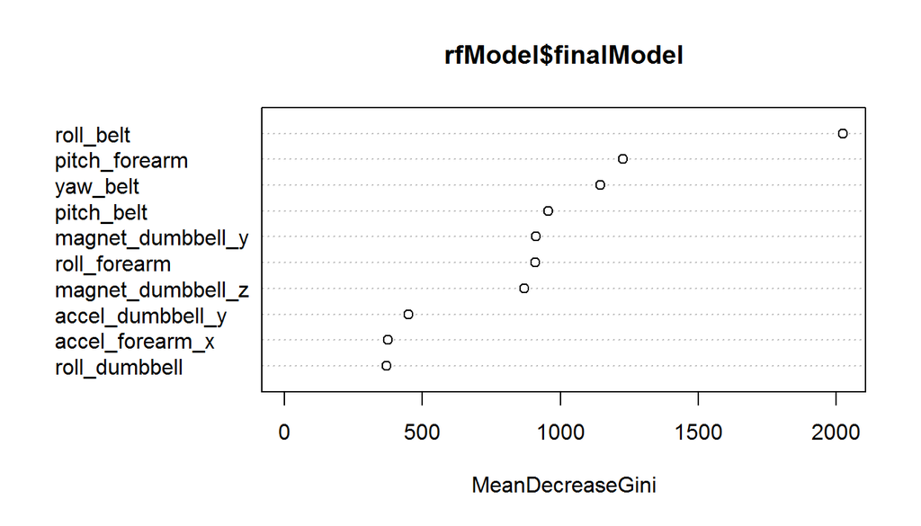

```r
varImpPlot(rfModel$finalModel, n.var=10)
```

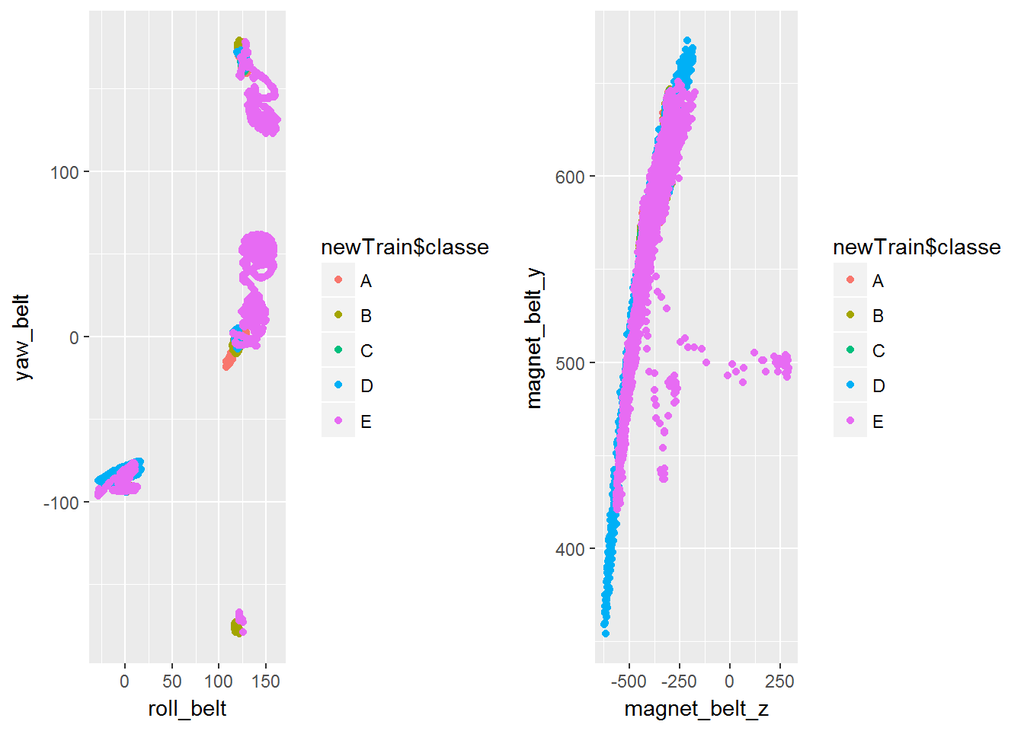

## Predicting Test Results

We can now use the random-forest model to predict our test results:

```r
finalPredictions <- predict(rfModel, testing)
```